# Psych 254 W15 PS #1

Kara Weisman

January 26, 2015

This is problem set #1, in which we hope you will practice the packages tidyr and dplyr. There are some great cheat sheets from [RStudio](http://www.rstudio.com/resources/cheatsheets/).

## The data set

This data set comes from a replication of [Janiszewski and Uy (2008)](http://dx.doi.org/10.1111/j.1467-9280.2008.02057.x), who investigated whether the precision of the anchor for a price influences the amount of adjustment.

In the data frame, the `Input.condition` variable represents the experimental condition (under the rounded anchor, the rounded anchor, over the rounded anchor). `Input.price1`, `Input.price2`, and `Input.price3` are the anchors for the `Answer.dog_cost`, `Answer.plasma_cost`, and `Answer.sushi_cost` items.

## Preliminaries

I pretty much always clear the workspace and load the same basic helper functions before starting an analysis.

```r
# setwd("/Users/kweisman/Documents/Coursework/PSYCH 254 Methods/psych254_materials/analyses")
rm(list=ls())
source("../helper/useful.R")
```

Note that I’m using a “relative” path (the “../helper”) rather than an absolute path (e.g. “/Users/mcfrank/code/projects/etc…”). The relative path means that someone else can run your code by changing to the right directory, while the absolute path will force someone else to make trivial changes every time they want to run it.

## Part 1: Data cleaning

The first part of this exercise actually just consists of getting the data in a format usable for analysis. This is not trivial. Let’s try it:

```r
d <- read.csv("../data/janiszewski_rep_exercise.csv")
```

Fine, right? Why can’t we go forward with the analysis?

## Check out data file

HINT: try computing some summary statistics for the different items. Also, are there any participants that did the task more than once?

Here, we will check out these data.

```r
# Save as a new dataset
d0 = d

# Examine variables
str(d0)
```

```
## 'data.frame':    90 obs. of  34 variables:
##  $ HITId                      : Factor w/ 3 levels "261WKUDD8XMBJ8COBQ261TO6T1XNCJ",..: 1 1 1 1 1 1 1 1 1 1 ...
##  $ HITTypeId                  : Factor w/ 1 level "2DVGTP9RA7S5C4ALLOJOM70JMHCRW9": 1 1 1 1 1 1 1 1 1 1 ...
##  $ Title                      : Factor w/ 1 level "How much is it worth? Quick 2 minute survey.": 1 1 1 1 1 1 1 1 1 1 ...
##  $ Description                : Factor w/ 1 level "A quick two minute survey asking about prices. DO THIS HIT ONLY ONCE.": 1 1 1 1 1 1 1 1 1 1 ...
##  $ Keywords                   : Factor w/ 1 level "survey, quick, prices": 1 1 1 1 1 1 1 1 1 1 ...
##  $ Reward                     : num  0.1 0.1 0.1 0.1 0.1 0.1 0.1 0.1 0.1 0.1 ...
##  $ CreationTime               : Factor w/ 1 level "Wed Jan 25 18:13:24 GMT 2012": 1 1 1 1 1 1 1 1 1 1 ...
##  $ MaxAssignments             : int  30 30 30 30 30 30 30 30 30 30 ...
##  $ RequesterAnnotation        : Factor w/ 1 level "Department:Other": 1 1 1 1 1 1 1 1 1 1 ...
##  $ AssignmentDurationInSeconds: int  600 600 600 600 600 600 600 600 600 600 ...
##  $ AutoApprovalDelayInSeconds : int  604800 604800 604800 604800 604800 604800 604800 604800 604800 604800 ...
##  $ Expiration                 : Factor w/ 1 level "Wed Feb 01 18:13:24 GMT 2012": 1 1 1 1 1 1 1 1 1 1 ...
##  $ NumberOfSimilarHITs        : int  2 2 2 2 2 2 2 2 2 2 ...
##  $ LifetimeInSeconds          : logi  NA NA NA NA NA NA ...
```

[output cut: 20 more lines]

```r
# Try to compute some summary stats
mean(d0$Answer.dog_cost) # Doesn't work, because coded as a factor
```

```
## [1] NA
```

```r
# Check for duplicate participants
count(d0, WorkerId)
```

```
## Source: local data frame [87 x 2]
##
##          WorkerId n
## 1  A10316ZXDCW4TT 1
## 2  A14U5M64AK4MAR 1
## 3  A16VNOCOSQS8H6 1
## 4  A17FFPDVAJ2SQJ 1
## 5  A18L9BY7DNA8D3 1
## 6  A1A70X1I06UZKH 1
## 7  A1DCWHY56LLX11 1
## 8  A1F0K96LA51ICQ 1
## 9  A1HQRT1UG6ERGL 1
## 10 A1IAC1SAII8YSO 1
## 11 A1JGZFWWT1KMVV 1
## 12 A1OKTCXWVYNXE6 1
```

[output cut: 75 more lines]

```r
subset(count(d0, WorkerId), n != 1) # one person did it 2x, and one person did it 3x
```

```
## Source: local data frame [2 x 2]
##
##         WorkerId n
## 1 A1VYX5VKZ0CTWU 3
## 2  A5IUO2T5MZQUZ 2
```

It looks like at least some variables are inappropriately stored as factors. Also, one participant did the task twice, and one participant did it three times! This means we have 3 duplicate observations (rows) that we need to delete.

## Cleaning data file

Fix the data file so that it looks reasonable.

First, we’ll recode variables.

```r
glimpse(d0)
```

```
## Variables:
## $ HITId                       (fctr) 261WKUDD8XMBJ8COBQ261TO6T1XNCJ, 2...
## $ HITTypeId                   (fctr) 2DVGTP9RA7S5C4ALLOJOM70JMHCRW9, 2...
## $ Title                       (fctr) How much is it worth? Quick 2 min...
## $ Description                 (fctr) A quick two minute survey asking ...
## $ Keywords                    (fctr) survey, quick, prices, survey, qu...
## $ Reward                      (dbl) 0.1, 0.1, 0.1, 0.1, 0.1, 0.1, 0.1,...
## $ CreationTime                (fctr) Wed Jan 25 18:13:24 GMT 2012, Wed...
## $ MaxAssignments              (int) 30, 30, 30, 30, 30, 30, 30, 30, 30...
## $ RequesterAnnotation         (fctr) Department:Other, Department:Othe...
## $ AssignmentDurationInSeconds (int) 600, 600, 600, 600, 600, 600, 600,...
## $ AutoApprovalDelayInSeconds  (int) 604800, 604800, 604800, 604800, 60...
## $ Expiration                  (fctr) Wed Feb 01 18:13:24 GMT 2012, Wed...
## $ NumberOfSimilarHITs         (int) 2, 2, 2, 2, 2, 2, 2, 2, 2, 2, 2, 2...
## $ LifetimeInSeconds           (lgl) NA, NA, NA, NA, NA, NA, NA, NA, NA...
```

[output cut: 20 more lines]

```r
# Not sure how to convert times to dates! Come back to this...
# Also not sure how to get rid of commas in input prices...
# d0[29:31] = as.numeric(gsub(",","", as.numeric(as.character(d0[29:31]))))
# gsub("([0-9])+\\,+([0-9])", "\\1\\2", as.character(d0[29,]))

# Convert answers to numeric form (new columns)
d0[35:40] <- tbl_df(d0[29:34]) %>% mutate_each("as.character") %>% mutate_each("as.numeric")
glimpse(d0)
```

```
## Variables:
## $ HITId                       (fctr) 261WKUDD8XMBJ8COBQ261TO6T1XNCJ, 2...
## $ HITTypeId                   (fctr) 2DVGTP9RA7S5C4ALLOJOM70JMHCRW9, 2...
## $ Title                       (fctr) How much is it worth? Quick 2 min...
## $ Description                 (fctr) A quick two minute survey asking ...
## $ Keywords                    (fctr) survey, quick, prices, survey, qu...
## $ Reward                      (dbl) 0.1, 0.1, 0.1, 0.1, 0.1, 0.1, 0.1,...
## $ CreationTime                (fctr) Wed Jan 25 18:13:24 GMT 2012, Wed...
## $ MaxAssignments              (int) 30, 30, 30, 30, 30, 30, 30, 30, 30...
## $ RequesterAnnotation         (fctr) Department:Other, Department:Othe...
## $ AssignmentDurationInSeconds (int) 600, 600, 600, 600, 600, 600, 600,...
## $ AutoApprovalDelayInSeconds  (int) 604800, 604800, 604800, 604800, 60...
## $ Expiration                  (fctr) Wed Feb 01 18:13:24 GMT 2012, Wed...
## $ NumberOfSimilarHITs         (int) 2, 2, 2, 2, 2, 2, 2, 2, 2, 2, 2, 2...
## $ LifetimeInSeconds           (lgl) NA, NA, NA, NA, NA, NA, NA, NA, NA...
```

[output cut: 26 more lines]

```r
# Remove old columns
d1 = d0[-32:-34]

glimpse(d1)
```

```
## Variables:
## $ HITId                       (fctr) 261WKUDD8XMBJ8COBQ261TO6T1XNCJ, 2...
## $ HITTypeId                   (fctr) 2DVGTP9RA7S5C4ALLOJOM70JMHCRW9, 2...
## $ Title                       (fctr) How much is it worth? Quick 2 min...
## $ Description                 (fctr) A quick two minute survey asking ...
## $ Keywords                    (fctr) survey, quick, prices, survey, qu...
## $ Reward                      (dbl) 0.1, 0.1, 0.1, 0.1, 0.1, 0.1, 0.1,...
## $ CreationTime                (fctr) Wed Jan 25 18:13:24 GMT 2012, Wed...
## $ MaxAssignments              (int) 30, 30, 30, 30, 30, 30, 30, 30, 30...
## $ RequesterAnnotation         (fctr) Department:Other, Department:Othe...
## $ AssignmentDurationInSeconds (int) 600, 600, 600, 600, 600, 600, 600,...
## $ AutoApprovalDelayInSeconds  (int) 604800, 604800, 604800, 604800, 60...
## $ Expiration                  (fctr) Wed Feb 01 18:13:24 GMT 2012, Wed...
## $ NumberOfSimilarHITs         (int) 2, 2, 2, 2, 2, 2, 2, 2, 2, 2, 2, 2...
## $ LifetimeInSeconds           (lgl) NA, NA, NA, NA, NA, NA, NA, NA, NA...
```

[output cut: 23 more lines]

Here, we remove duplicate participants, by including only the first attempt submitted by each participant.

```r
# Group observations by WorkerId, and then select first submitted attempt for each worker
d2 = tbl_df(d1) %>% group_by(WorkerId) %>% top_n(1, SubmitTime)

# Check how many observations are left: should be 3 fewer than before
length(d0$WorkerId) - length(d1$WorkerId) == 3
```

```
## [1] FALSE
```

```r
str(d2)
```

```
## Classes 'grouped_df', 'tbl_df', 'tbl' and 'data.frame':  87 obs. of  37 variables:
##  $ HITId                      : Factor w/ 3 levels "261WKUDD8XMBJ8COBQ261TO6T1XNCJ",..: 1 1 1 1 1 1 1 1 1 1 ...
##  $ HITTypeId                  : Factor w/ 1 level "2DVGTP9RA7S5C4ALLOJOM70JMHCRW9": 1 1 1 1 1 1 1 1 1 1 ...
##  $ Title                      : Factor w/ 1 level "How much is it worth? Quick 2 minute survey.": 1 1 1 1 1 1 1 1 1 1 ...
##  $ Description                : Factor w/ 1 level "A quick two minute survey asking about prices. DO THIS HIT ONLY ONCE.": 1 1 1 1 1 1 1 1 1 1 ...
##  $ Keywords                   : Factor w/ 1 level "survey, quick, prices": 1 1 1 1 1 1 1 1 1 1 ...
##  $ Reward                     : num  0.1 0.1 0.1 0.1 0.1 0.1 0.1 0.1 0.1 0.1 ...
##  $ CreationTime               : Factor w/ 1 level "Wed Jan 25 18:13:24 GMT 2012": 1 1 1 1 1 1 1 1 1 1 ...
##  $ MaxAssignments             : int  30 30 30 30 30 30 30 30 30 30 ...
##  $ RequesterAnnotation        : Factor w/ 1 level "Department:Other": 1 1 1 1 1 1 1 1 1 1 ...
##  $ AssignmentDurationInSeconds: int  600 600 600 600 600 600 600 600 600 600 ...
##  $ AutoApprovalDelayInSeconds : int  604800 604800 604800 604800 604800 604800 604800 604800 604800 604800 ...
##  $ Expiration                 : Factor w/ 1 level "Wed Feb 01 18:13:24 GMT 2012": 1 1 1 1 1 1 1 1 1 1 ...
##  $ NumberOfSimilarHITs        : int  2 2 2 2 2 2 2 2 2 2 ...
##  $ LifetimeInSeconds          : logi  NA NA NA NA NA NA ...
```

[output cut: 25 more lines]

We have now finished cleaning our data.

## Part 2: Making these data tidy

Now let’s start with the cleaned data, so that we are all beginning from the same place.

```r
d <- read.csv("../data/janiszewski_rep_cleaned.csv")
```

This data frame is in *wide* format - that means that each row is a participant and there are multiple observations per participant. This data is not *tidy*.

To make this data tidy, we’ll do some cleanup. First, remove the columns you don’t need, using the verb `select`.

HINT: `?select` and the examples of helper functions will help you be efficient.

```r
# Select only variables of interest
d.tidy <- select(d, WorkerId, WorkTimeInSeconds, Input.condition, starts_with("Answer"))
```

Try renaming some variables using `rename`. A good naming scheme is:

- consistent with case
- consistent with “.” or “_" ( “_" is usually preferred)
- concise as will be comprehensible to others

Try using the `%>%` operator as well. So you will be “piping” `d %>% rename(...)`.

```r
# Change uppercase to lowercase
names(d.tidy) <- tolower(names(d.tidy))

# Change "." to "_"
names(d.tidy) <- gsub("\\.", "_", names(d.tidy))

# Choose better names for some variables
d.tidy <- d.tidy %>%
  rename(ids = workerid,
         task_time = worktimeinseconds,
         condition = input_condition)

names(d.tidy)
```

```
## [1] "ids"                "task_time"          "condition"
## [4] "answer_dog_cost"    "answer_plasma_cost" "answer_sushi_cost"
```

```r
head(d.tidy)
```

```
##              ids task_time condition answer_dog_cost answer_plasma_cost
## 1 A18L9BY7DNA8D3        23      over            2300               4800
## 2 A1YGOYNWW3Q9SQ       228      over            2450               4850
## 3 A2JKCS6UCAUARS        89      over             800               1200
## 4 A3IM0Z8F01XLE6       145      over            2000               4200
## 5 A21JRS3L6PMJ5Q       232      over            2000               4500
## 6 A1ZLYD5GP1FLYL        86      over            1600               4600
##   answer_sushi_cost
## 1               8.7
## 2               9.0
## 3               8.0
## 4               9.0
## 5               8.5
## 6               8.0
```

OK, now for the tricky part. Use the verb *gather* to turn this into a *tidy* data frame.

HINT: look for online examples!

```r
d.tidy2 <- d.tidy %>%
  gather(question, est_cost, -ids, -task_time, -condition) %>%
  arrange(ids)

head(d.tidy2)
```

```
##              ids task_time condition           question est_cost
## 1 A10316ZXDCW4TT       181   rounded    answer_dog_cost  2000.00
## 2 A10316ZXDCW4TT       181   rounded answer_plasma_cost  4300.00
## 3 A10316ZXDCW4TT       181   rounded  answer_sushi_cost     8.25
## 4 A14U5M64AK4MAR        66     under    answer_dog_cost  2100.00
## 5 A14U5M64AK4MAR        66     under answer_plasma_cost  3500.00
## 6 A14U5M64AK4MAR        66     under  answer_sushi_cost     6.99
```

Bonus problem: *spread* these data back into a wide format data frame.

```r
d.wide <- d.tidy2 %>%
  spread(question, est_cost) %>%
  arrange(ids)

head(d.wide)
```

```
##              ids task_time condition answer_dog_cost answer_plasma_cost
## 1 A10316ZXDCW4TT       181   rounded            2000               4300
## 2 A14U5M64AK4MAR        66     under            2100               3500
## 3 A16VNOCOSQS8H6       177     under            2000               2500
## 4 A17FFPDVAJ2SQJ        88      over            1875               4699
## 5 A18L9BY7DNA8D3        23      over            2300               4800
## 6 A1A70X1I06UZKH       194     under            2192               4888
##   answer_sushi_cost
## 1              8.25
## 2              6.99
## 3              7.80
## 4              7.89
## 5              8.70
## 6              7.50
```

## Part 3: Manipulating the data using dplyr

Try also using the dplyr `distinct` function to remove the duplicate participants from the raw csv file that you discovered in part 1.

```r
d.raw <- read.csv("../data/janiszewski_rep_exercise.csv")
d.unique.subs <- distinct(d.raw, WorkerId)
```

As we said in class, a good thing to do is always to check histograms of the response variable. Do that now, using either regular base graphics or ggplot. What can you conclude?

```
## stat_bin: binwidth defaulted to range/30. Use 'binwidth = x' to adjust this.
## stat_bin: binwidth defaulted to range/30. Use 'binwidth = x' to adjust this.
## stat_bin: binwidth defaulted to range/30. Use 'binwidth = x' to adjust this.
```

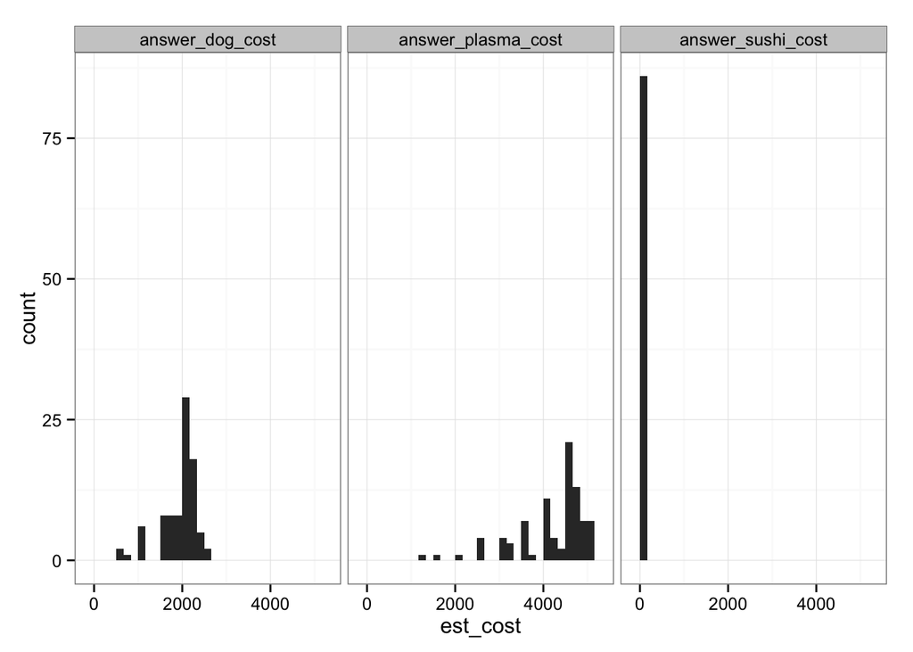

```r
qplot(x = est_cost, facets = ~ question, data = d.tidy2)
```

```
## stat_bin: binwidth defaulted to range/30. Use 'binwidth = x' to adjust this.
```

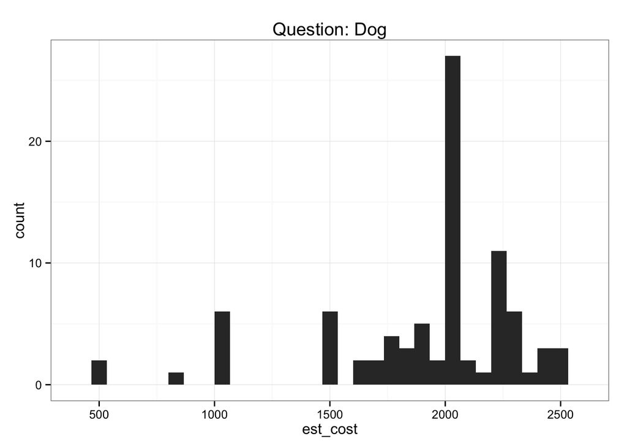

```r
# Look at each question alone... should be a way to do this with tidyr, right??
qplot(est_cost, data = subset(d.tidy2, question == "answer_dog_cost"), main = "Question: Dog")
```

```
## stat_bin: binwidth defaulted to range/30. Use 'binwidth = x' to adjust this.
```

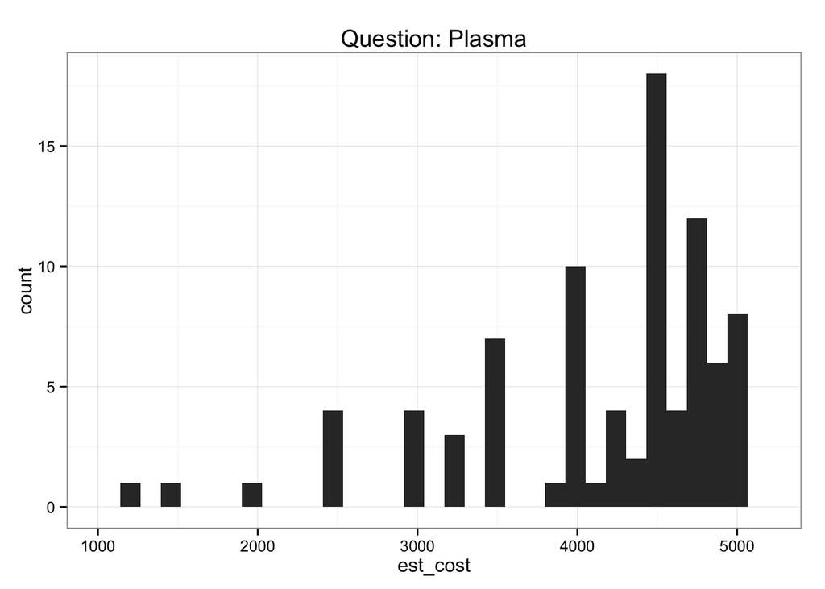

```r
qplot(est_cost, data = subset(d.tidy2, question == "answer_plasma_cost"), main = "Question: Plasma")
```

```
## stat_bin: binwidth defaulted to range/30. Use 'binwidth = x' to adjust this.
```

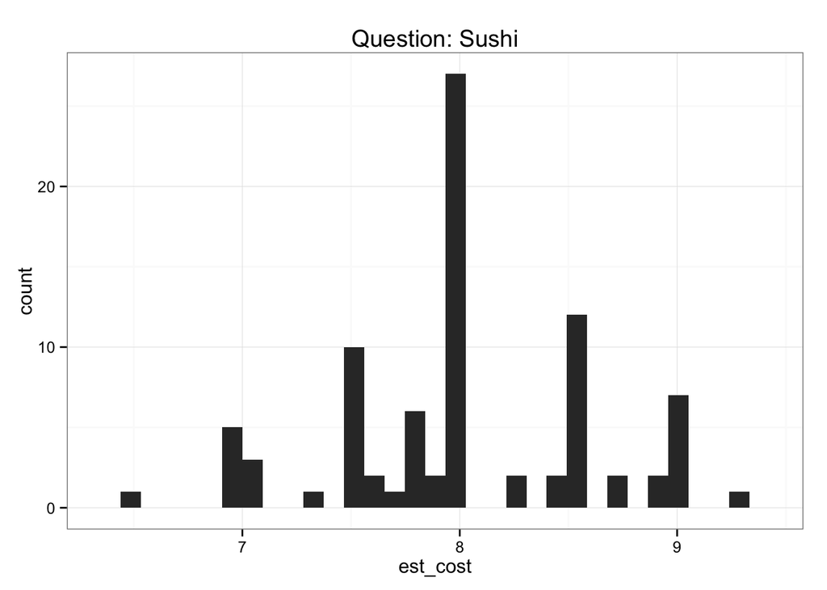

```r
qplot(est_cost, data = subset(d.tidy2, question == "answer_sushi_cost"), main = "Question: Sushi")
```

First of all, answers to the three different questions have very different ranges! (This makes sense, given how we should expect an order of sushi, e.g., to cost much less than a dog.) Answers to the plasma question, and to a lesser extent the dog question, appear to be somewhat negatively skewed, but answers to the sushi question seem fairly normal. We might want to consider transforming our data… but maybe not.

OK, now we turn to the actual data anlysis. We’ll be using dplyr verbs to `filter`, `group`,`mutate`, and `summarise` the data.

Start by using `summarise` on `d.tidy` to compute the mean bet across all participants. Note that this is simply taking the grand mean. Ultimately, we would like to compute the mean for different conditions and items, but this will come later. Right now we’re just learning the syntax of `summarise`.

```r
summarise(d.tidy2, mean(est_cost, na.rm = T)) # hm, seems like we left some "NAs" in there somewhere...
```

```
##   mean(est_cost, na.rm = T)
## 1                      2023
```

This is a great time to get comfortable with the `%>%` operator. In brief, `%>%` allows you to pipe data from one function to another. So if you would have written:

```r
#d <- function(d, other_stuff)
```

you can now write:

```r
#d <- d %>% function(other_stufF)
```

That doesn’t seem like much, but it’s cool when you can replace:

```r
# d <- function1(d, other_stuff)
# d <- function2(d, lots_of_other_stuff, more_stuff)
# d <- function3(d, yet_more_stuff)
```

with

```r
# d <- d %>%
#   function1(other_stuff) %>%
#   function2(lots_of_other_stuff, more_stuff) %>%
#   function3(yet_more_stuff)
```

In other words, you get to make a clean list of the things you want to do and chain them together without a lot of intermediate assignments.

Let’s use that capacity to combine `summarise` with `group_by`, which allows us to break up our summary into groups. Try grouping by item and condition and taking means using `summarise`, chaining these two verbs with `%>%`.

```r
d.tidy2 %>%
  group_by(question) %>%
  summarise(mean(est_cost, na.rm = T))
```

```
## Source: local data frame [3 x 2]
##
##             question mean(est_cost, na.rm = T)
## 1    answer_dog_cost                   1896.48
## 2 answer_plasma_cost                   4140.02
## 3  answer_sushi_cost                      8.01
```

OK, it’s looking like there are maybe some differences between conditions, but how are we going to plot these? They are fundamentally different magnitudes from one another.

Really we need the size of the deviation from the anchor, which means we need the anchor value (the `Input.price` variables that we’ve ignored up until now). Let’s go back to the data and add that in.

Take a look at this complex expression. You don’t have to modify it, but see what is being done here with gather, separate and spread. Run each part (e.g. the first verb, the first two verbs, etc.) and after doing each, look at `head(d.tidy)` to see what they do.

```r
d.tidy <- d %>%
  select(WorkerId, Input.condition,
         starts_with("Answer"),
         starts_with("Input")) %>%
  rename(workerid = WorkerId,
         condition = Input.condition,
         plasma_anchor = Input.price1,
         dog_anchor = Input.price2,
         sushi_anchor = Input.price3,
         dog_cost = Answer.dog_cost,
         plasma_cost = Answer.plasma_cost,
         sushi_cost = Answer.sushi_cost) %>%
  gather(name, cost,
         dog_anchor, plasma_anchor, sushi_anchor,
         dog_cost, plasma_cost, sushi_cost) %>%
  separate(name, c("item", "type"), sep = "_") %>%
  spread(type, cost)
```

Now we can do the same thing as before but look at the relative difference between anchor and estimate. Let’s do this two ways:

- By computing absolute value of percentage change in price, and
- By computing z-scores over items.

To do the first, use the `mutate` verb to add a percent change column, then comute the same summary as before.

```r
pcts <- d.tidy %>%
  mutate(pct_change = abs((cost - anchor)/anchor))

pcts %>%
  group_by(condition) %>%
  summarise(mean(pct_change, na.rm = T))
```

```
## Source: local data frame [3 x 2]
##
##   condition mean(pct_change, na.rm = T)
## 1      over                      0.1659
## 2   rounded                      0.1813
## 3     under                      0.1777
```

I don’t see very much evidence for differences here…

To do the second, you will need to `group` first by item, compute z-scores with respect to items, then further group by condition.

HINT: `scale(x)` returns a complicated data structure that doesn’t play nicely with dplyr. try `scale(x)[,1]` to get what you need.

HINT: by default, `group_by` undoes any previous groupings. If you want to add new grouping variables *on top* of pre-existing ones, specify `add = TRUE`, e.g., `d %>% group_by(var1) %>% group_by(var2, add = TRUE)`.

```r
z.scores <- d.tidy %>%
  group_by(item, add = TRUE) %>%
  mutate(z = scale(cost)[,1])

z.scores %>%
  group_by(condition) %>%
  summarise(mean(z, na.rm = T))
```

```
## Source: local data frame [3 x 2]
##
##   condition mean(z, na.rm = T)
## 1      over             0.2405
## 2   rounded            -0.0597
## 3     under            -0.1930
```

OK, now here comes the end: we’re going to plot the differences and see if anything happened. First the percent change:

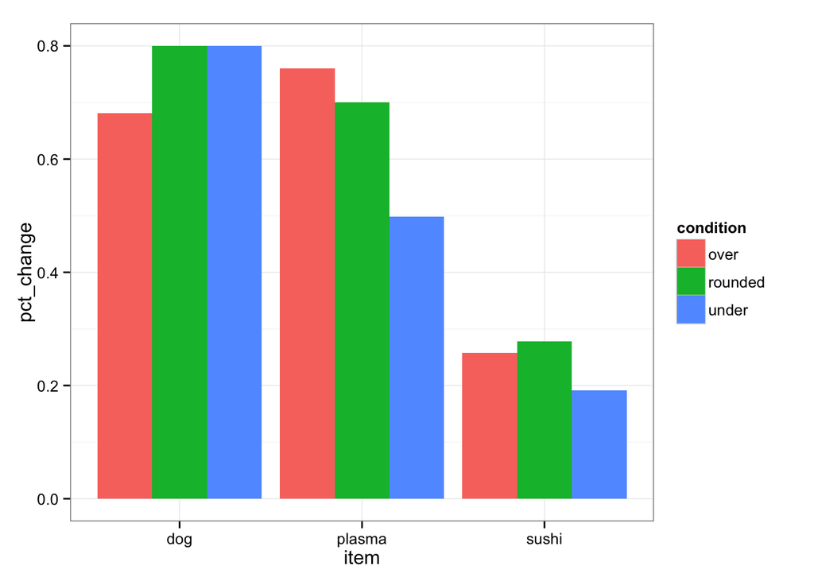

```r
qplot(item, pct_change, fill=condition,
      position="dodge",
      stat="identity", geom="bar",
      data=pcts)
```

and the z-scores:

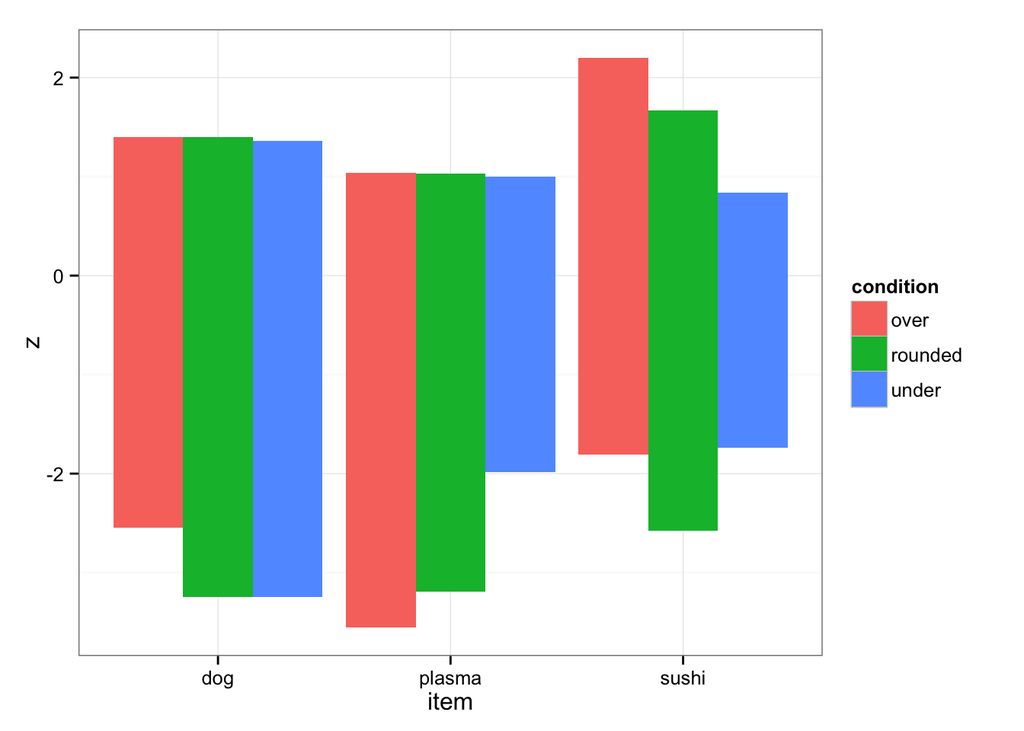

```r
qplot(item, z, fill=condition,
      position="dodge",
      stat="identity", geom="bar",
      data=z.scores)
```

Oh well. This replication didn’t seem to work out straightforwardly.